# TSRethinking8 Vector autoregressive models

Wayne Zhang

10/9/2021

```r
knitr::opts_chunk$set(fig.width = 8, fig.height = 4)
rm(list=ls())  # remove variables
library(mFilter)
library(vars)
library(FinCal)
library(zoo)
library(tidyverse)
```

# 1 Vector autoregressive models

## 1.1 VAR(1)

### 1.1.1 Notation

- To describe the use of multivariate techniques, we need to introduce new notation:
  - Small letters denote a $(K \times 1)$ vector of random variables, where

$$\begin{eqnarray}
\boldsymbol{y}_{t}=(y_{1,t}, \ldots ,y_{K,t})^{^{\prime }}
\end{eqnarray}$$

- The VAR model of order $p$ can then be written as,
  $$\boldsymbol{y}_t = A_1 \boldsymbol{y}_{t-1} + \ldots + A_p \boldsymbol{y}_{t-p} + CD_t + \boldsymbol{u}_t$$
- where $A_j$ is a $(K\times K)$ coefficient matrix, for $j=\{ 1, \ldots , p\}$
- $C$ is the coefficient matrix for deterministic regressors
- $D_t$ is the matrix for deterministic regressors
- $\boldsymbol{u}_t$ is a $(K\times 1)$ dimension vector of error terms
- The vector of error terms are assumed to be white noise

$$\begin{eqnarray}
\mathbb{E} \left[ \boldsymbol{u}_t \right] ;=;0 \\
\mathbb{E} \left[ \boldsymbol{u}_t \boldsymbol{u}_t^\prime \right] ;=; \Sigma_{\boldsymbol{u}} \; \text{which is positive definite}
\end{eqnarray}$$

- This VAR is termed a reduced-form representation, which differs to the structural VAR (SVAR) that is discussed later

Example:

- For simplicity, assume $K=2$, and $p=1$,
  $$\begin{eqnarray}
  \boldsymbol{y}_{t}= A_{1} \boldsymbol{y}_{t-1} + \boldsymbol{u}_{t}
  \end{eqnarray}$$
- where $y_{t}$, $\mu$, $A_{1}$, and $\boldsymbol{u}_{t}$ are given as,
  $$\begin{eqnarray}
  \boldsymbol{y}_{t}=\left[
  \begin{array}{c} y_{1,t} \\ y_{2,t} \end{array}
  \right] , A_{1}=\left[
  \begin{array}{cc} \alpha_{11} ; \alpha_{12} \\ \alpha_{21} ; \alpha_{22} \end{array}
  \right] \textrm{ and } \boldsymbol{u}_{t}=\left[
  \begin{array}{c} u_{1,t} \\ u_{2,t} \end{array}
  \right]
  \end{eqnarray}$$
- For example, assume the elements of $A_{1}$ are given as,
  $$\begin{eqnarray}
  \left[
  \begin{array}{c} y_{1,t} \\ y_{2,t} \end{array}
  \right] = \left[
  \begin{array}{cc} 0.5 ; 0 \\ 1 ; 0.2 \end{array}
  \right] \left[
  \begin{array}{c} y_{1,t-1} \\ y_{2,t-1} \end{array}
  \right] +\left[
  \begin{array}{c} u_{1,t} \\ u_{2,t} \end{array}
  \right]
  \end{eqnarray}$$
- where after some matrix manipulations,
  $$\begin{eqnarray}
  y_{1,t} ;=; 0.5y_{1,t-1}+u_{1,t} \\
  y_{2,t} ;=; 1y_{1,t-1}+0.2y_{2,t-1}+u_{2,t}
  \end{eqnarray}$$
- The above model suggests:
  - $y_{2,t}$ depends on past values of itself and past values of $y_{1,t}$
  - $y_{1,t}$ only depends on past values of itself

## 1.2 VAR(p)

$$\begin{eqnarray}
Z_{t}=\Gamma_{0}+\Gamma_{1}Z_{t-1}+\Upsilon_{t}
\end{eqnarray}$$
where we have,
$$\begin{eqnarray}
Z_{t}=\left[
\begin{array}{c} \boldsymbol{y}_{t} \\ \boldsymbol{y}_{t-1} \\ \vdots \\ \boldsymbol{y}_{t-p+1} \end{array}
\right] , \hspace{1cm} \Gamma_0=\left[
\begin{array}{c} \mu \\ 0 \\ \vdots \\ 0 \end{array}
\right] , \hspace{1cm} \Upsilon_{t} =\left[
\begin{array}{c} \boldsymbol{u}_{t} \\ 0 \\ \vdots \\ 0 \end{array}
\right]
\end{eqnarray}$$
the matrix notation is
$$\begin{eqnarray}
\left[
\begin{array}{c} \boldsymbol{y}_{t} \\ \boldsymbol{y}_{t-1} \\ \boldsymbol{y}_{t-2} \\ \vdots \\ \boldsymbol{y}_{t-p+1} \end{array}
\right] =\left[
\begin{array}{c} \mu \\ 0 \\ 0 \\ \vdots \\ 0 \end{array}
\right] +\left[
\begin{array}{ccccccc} A_{1} & A_{2} & \cdots & A_{p-1} & A_{p} \\ I & 0 & \cdots & 0 & 0 \\ 0 & I & \cdots & 0 & 0 \\ \vdots & \vdots & \ddots & \vdots & \vdots \\ 0 & 0 & \cdots & I & 0 \end{array}
\right]
\left[
\begin{array}{c} \boldsymbol{y}_{t-1} \\ \boldsymbol{y}_{t-2} \\ \boldsymbol{y}_{t-3} \\ \vdots \\ \boldsymbol{y}_{t-p} \end{array}
\right] +
\left[
\begin{array}{c} \boldsymbol{u}_{t} \\ 0 \\ 0 \\ \vdots \\ 0 \end{array}
\right]
\end{eqnarray}$$

### 1.2.1 Stationary condition of VAR

The weakly stationary condition is the TS converges to mean, in one dimension case is $|\phi|<1$ for multi-demension case is eigenvalues less than one in absolute value.

The eigenvalue defined by:

$$|\Gamma_{1}-\lambda I|=0$$

and the characteristic function of VAR model is

$$|I-\Gamma_{1}z|$$

where the interpretation is reversed, as a stable stochastic process has characteristic roots that lie outside the unit circle.

### 1.2.2 Wold representation

Just as the stable AR(p) model has a MA representation, the stable VAR(p) has a VMA representation - termed the Wold decomposition

- Theorem states that every covariance-stationary time series can be written as the sum of two uncorrelated processes:
  - deterministic component, $\kappa_{t}$, (which could be the mean)
  - infinite moving average representation of $\sum_{j=0}^{\infty }\theta_{j} \varepsilon_{t-j}$
- Hence,
  $$\begin{eqnarray}
  y_{t}=\sum_{j=0}^{\infty }\theta_{j} \varepsilon_{t-j}+\kappa_{t}
  \end{eqnarray}$$
- where we assume $\theta_{0}=1$
- $\sum_{j=0}^{\infty }|\theta_{j}|<\infty$
- $\varepsilon_{t}$ is white noise

**Example: VAR(1)**

$$\boldsymbol{y}_{t}=\mu +A_{1}\boldsymbol{y}_{t-1}+\boldsymbol{u}_{t}$$

Using the lag operator,

$$(I-A_{1}L)\boldsymbol{y}_{t}=\mu +\boldsymbol{u}_{t}$$

Using the expression, $(I-A_{1}L)=A(L)$ we can write,

$$A(L)\boldsymbol{y}_{t}=\mu +\boldsymbol{u}_{t}$$

Using the geometric rule:

$$A(L)^{-1}=(I-A_{1}L)^{-1}=\sum_{j=0}^{p}A_{1}^{j}L^{j}\equiv B(L)=\sum_{j=0}^{\infty }B_{j}L^{j}$$

$$\begin{eqnarray}
\boldsymbol{y}_{t} =A(L)^{-1}\mu +A(L)^{-1}\boldsymbol{u}_{t} \\
=B(L)\mu +B(L) \boldsymbol{u}_t \\
=\varphi+\sum_{j=0}^{\infty }B_{j}\boldsymbol{u}_{t-j}
\end{eqnarray}$$

with $B_{0}=I$ and $\varphi=\left( \sum\limits_{j=0}^{\infty }B_{j}\right) \mu$.

The MA coefficients, $B_{j}$, are derived from the relationship $I=B(L)A(L)$

$$\begin{eqnarray}
I&=&B(L)A(L) \\
I &=&(B_{0}+B_{1}L+B_{2}L^{2}+ \ldots )(I-A_{1}L-A_{2}L^{2}- \ldots - A_{p}L^{p}) \\
&=&[B_{0}+B_{1}L+B_{2}L^{2}+ \ldots ] \\
&& -[B_{0}A_{1}L+B_{1}A_{1}L^{2}+B_{2}A_{1}L^{3}+ \ldots ] \\
&& -[B_{0}A_{2}L^{2}+B_{1}A_{2}L^{3}+B_{2}A_{2}L^{4}+ \ldots] - \ldots \\
&=&B_{0}+(B_{1}-B_{0}A_{1})L+(B_{2}-B_{1}A_{1}-B_{0}A_{2})L^{2}+ \ldots \\
&& +\left(B_{p}-\sum_{j=1}^{i}B_{p-j}A_{j}\right) L^{p}+ \ldots
\end{eqnarray}$$

Solving for the relevant lags, we get:

$$\begin{eqnarray}
B_{0} &=&I \\
B_{1} &=&B_{0}A_{1} \\
B_{2} &=&B_{1}A_{1}+B_{0}A_{2} \\
\vdots & & \vdots \\
B_{i} &=&\sum_{j=1}^{i}B_{i-j}A_{j}\hspace{1cm}\text{for }i=1,2, \ldots
\end{eqnarray}$$

### 1.2.4 VAR in emperical study

#### 1.2.4.1 Test data

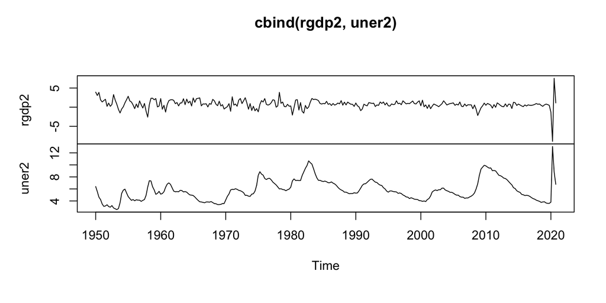

```r
# dat <- read.csv(file = "/Users/waynezhang/OneDrive - UW-Madison/IOS-WIN/Fall 2021/Econ 706/TimeSeries/LectureNotes/T10-var/blanchQua.csv")
# gdp <- ts(dat$GDP, start = c(1948, 2), freq = 4)
# une <- ts(dat$U, start = c(1948, 2), freq = 4)
# plot(cbind(gdp, une))

rgdp_growth <- fred("GDPC1", "1949-10-01", "2020-12-31")[, -1] %>%
    mutate(growth = 100*(price/lag(price) - 1)) %>%
    drop_na()
uner <- fred("UNRATE", "1950-01-01", "2020-12-31")[, -1] %>%
  mutate(date2 = as.yearqtr(date)) %>%
  group_by(date2) %>%
  summarise(price2 = mean(price))
rgdp2 <- ts(rgdp_growth$growth, start = c(1950, 1), freq = 4)
uner2 <- ts(uner$price2, start = c(1950, 1), freq = 4)
plot(cbind(rgdp2, uner2))
```

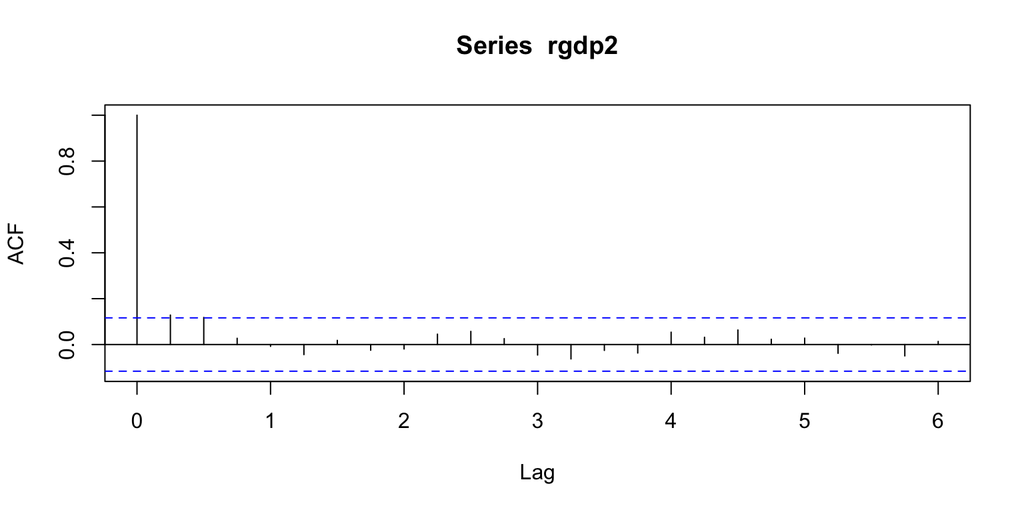

```r
# To consider the degree of persistence in the data we make use of the autocorrelation function.
acf(rgdp2)
```

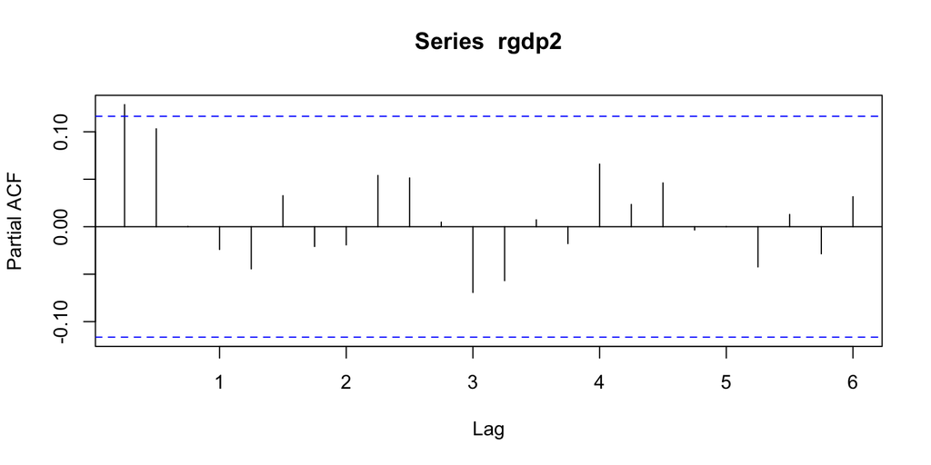

```r
pacf(rgdp2)
```

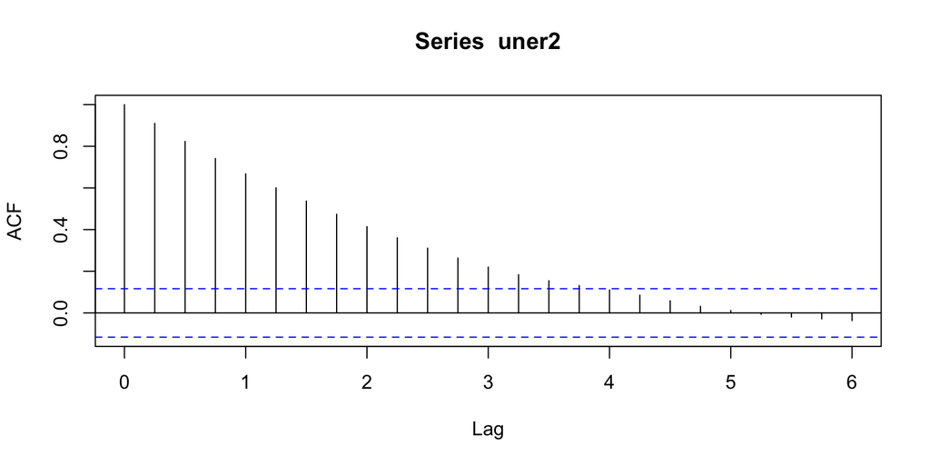

```r
acf(uner2)
```

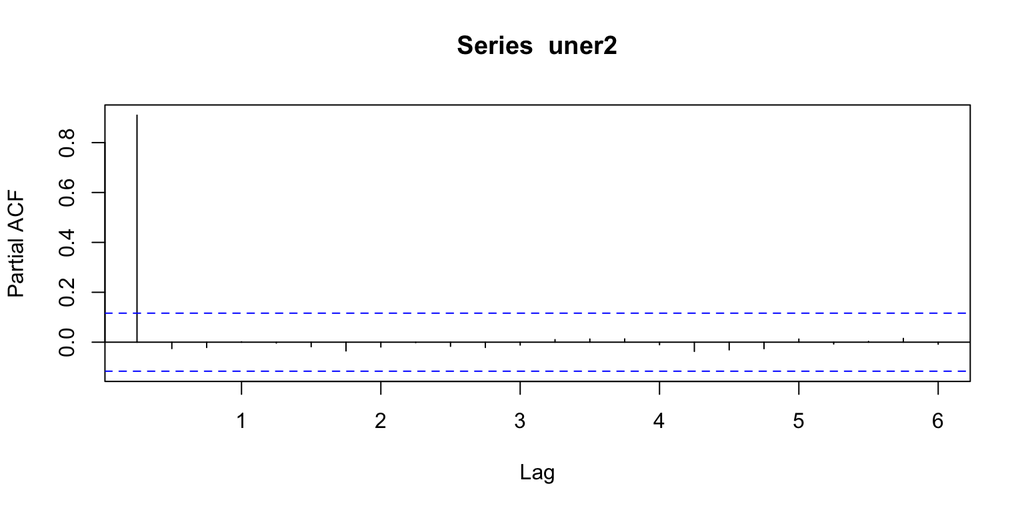

```r
pacf(uner2)
```

```r
# eliminate uniroot case: Dickey-Fuller test
# H0: The time series is non-stationary
# H1: The time series is stationary.
adf.une <- ur.df(uner2, type = "trend", selectlags = "AIC")
summary(adf.une) #  p-value: 0.003342 < 0.05 thus, reject the null hypothesis
```

```
##
## ###############################################
## # Augmented Dickey-Fuller Test Unit Root Test #
## ###############################################
##
## Test regression trend
##
##
## Call:
## lm(formula = z.diff ~ z.lag.1 + 1 + tt + z.diff.lag)
##
## Residuals:
##     Min      1Q  Median      3Q     Max
## -3.8064 -0.2435 -0.0933  0.1212  8.9888
##
## Coefficients:
##               Estimate Std. Error t value Pr(>|t|)
## (Intercept)  0.4844643  0.1570595   3.085 0.002244 **
## z.lag.1     -0.0968797  0.0261618  -3.703 0.000257 ***
## tt           0.0005624  0.0005345   1.052 0.293626
## z.diff.lag   0.0175490  0.0607496   0.289 0.772893
## ---
## Signif. codes:  0 '***' 0.001 '**' 0.01 '*' 0.05 '.' 0.1 ' ' 1
##
## Residual standard error: 0.7069 on 278 degrees of freedom
## Multiple R-squared:  0.048,  Adjusted R-squared:  0.03773
## F-statistic: 4.673 on 3 and 278 DF,  p-value: 0.003342
##
##
## Value of test-statistic is: -3.7031 4.5803 6.8646
##
## Critical values for test statistics:
##       1pct  5pct 10pct
## tau3 -3.98 -3.42 -3.13
## phi2  6.15  4.71  4.05
## phi3  8.34  6.30  5.36
```

#### 1.2.4.2 building model

```r
dat.bv <- cbind(rgdp2, uner2)
colnames(dat.bv) <- c("gdp", "une")

# order selection
VARselect(dat.bv, lag.max = 12, type = "const") # const (constant) mean there is no trend but with constant term
```

```
## $selection
## AIC(n)  HQ(n)  SC(n) FPE(n)
##      4      2      2      4
##
## $criteria
##                 1          2          3          4          5          6
## AIC(n) -1.4369450 -1.5532763 -1.5657813 -1.5796199 -1.5612862 -1.5620814
## HQ(n)  -1.4050125 -1.5000555 -1.4912723 -1.4838225 -1.4442006 -1.4237075
## SC(n)  -1.3574052 -1.4207100 -1.3801886 -1.3410006 -1.2696405 -1.2174091
## FPE(n)  0.2376531  0.2115555  0.2089295  0.2060634  0.2098845  0.2097297
##                 7         8          9         10         11         12
## AIC(n) -1.5527677 -1.532516 -1.5217290 -1.5135976 -1.4890464 -1.4851877
## HQ(n)  -1.3931055 -1.351566 -1.3194902 -1.2900705 -1.2442310 -1.2190839
## SC(n)  -1.1550690 -1.081791 -1.0179773 -0.9568194 -0.8792417 -0.8223564
## FPE(n)  0.2117088  0.216062  0.2184336  0.2202522  0.2257704  0.2266956
```

```r
# for VAR model order as small as possible
bv.est <- VAR(dat.bv, p = 2, type = "const", season = NULL, exogen = NULL)
summary(bv.est)
```

```
##
## VAR Estimation Results:
## =========================
## Endogenous variables: gdp, une
## Deterministic variables: const
## Sample size: 282
## Log Likelihood: -574.934
## Roots of the characteristic polynomial:
## 0.8877 0.4974 0.2289 0.2289
## Call:
## VAR(y = dat.bv, p = 2, type = "const", exogen = NULL)
##
##
## Estimation results for equation gdp:
## ====================================
## gdp = gdp.l1 + une.l1 + gdp.l2 + une.l2 + const
##
##        Estimate Std. Error t value Pr(>|t|)
## gdp.l1  0.53665    0.08859   6.058 4.48e-09 ***
## une.l1  0.99013    0.14498   6.829 5.39e-11 ***
## gdp.l2  0.19868    0.05902   3.366 0.000869 ***
## une.l2 -0.85990    0.14590  -5.894 1.09e-08 ***
## const  -0.56181    0.25119  -2.237 0.026109 *
## ---
## Signif. codes:  0 '***' 0.001 '**' 0.01 '*' 0.05 '.' 0.1 ' ' 1
##
##
## Residual standard error: 1.044 on 277 degrees of freedom
## Multiple R-Squared: 0.184,   Adjusted R-squared: 0.1723
## F-statistic: 15.62 on 4 and 277 DF,  p-value: 1.544e-11
##
##
## Estimation results for equation une:
## ====================================
## une = gdp.l1 + une.l1 + gdp.l2 + une.l2 + const
##
##        Estimate Std. Error t value Pr(>|t|)
## gdp.l1 -0.35875    0.05568  -6.443 5.17e-10 ***
## une.l1  0.44244    0.09113   4.855 2.01e-06 ***
## gdp.l2 -0.07993    0.03710  -2.155    0.032 *
## une.l2  0.46237    0.09170   5.042 8.33e-07 ***
## const   0.89480    0.15788   5.667 3.63e-08 ***
## ---
## Signif. codes:  0 '***' 0.001 '**' 0.01 '*' 0.05 '.' 0.1 ' ' 1
##
##
## Residual standard error: 0.6563 on 277 degrees of freedom
## Multiple R-Squared: 0.8545,  Adjusted R-squared: 0.8524
## F-statistic: 406.8 on 4 and 277 DF,  p-value: < 2.2e-16
##
##
##
## Covariance matrix of residuals:
##         gdp     une
## gdp  1.0902 -0.5099
## une -0.5099  0.4307
##
## Correlation matrix of residuals:
##        gdp    une
## gdp  1.000 -0.744
## une -0.744  1.000
```

As Roots of the characteristic polynomial: 0.8877 0.4974 0.2289 0.2289 less than 1, we can say this system is stable.

#### 1.2.4.3 test the model

```r
# test the residuals are white noise, i.e. test the model fitness
#  the null hypothesis specifies values for a vector of parameters that are thought of as being on an equal footing, & the alternative is that at least one parameter value is different from that specified by the null.
bv.serial <- serial.test(bv.est, lags.pt = 12, type = "PT.asymptotic")
bv.serial # p-value = 0.7274 in this case we accept the null hypothesis, i.e. the residuals are white noise
```

```
##
##  Portmanteau Test (asymptotic)
##
## data:  Residuals of VAR object bv.est
## Chi-squared = 34.218, df = 40, p-value = 0.7274
```

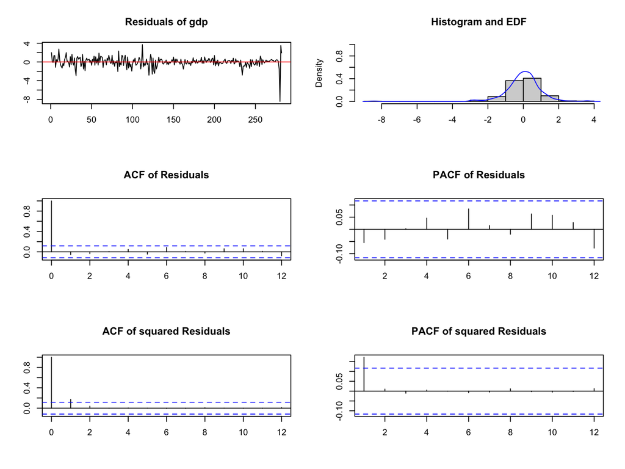

```r
plot(bv.serial, names = "gdp")
```

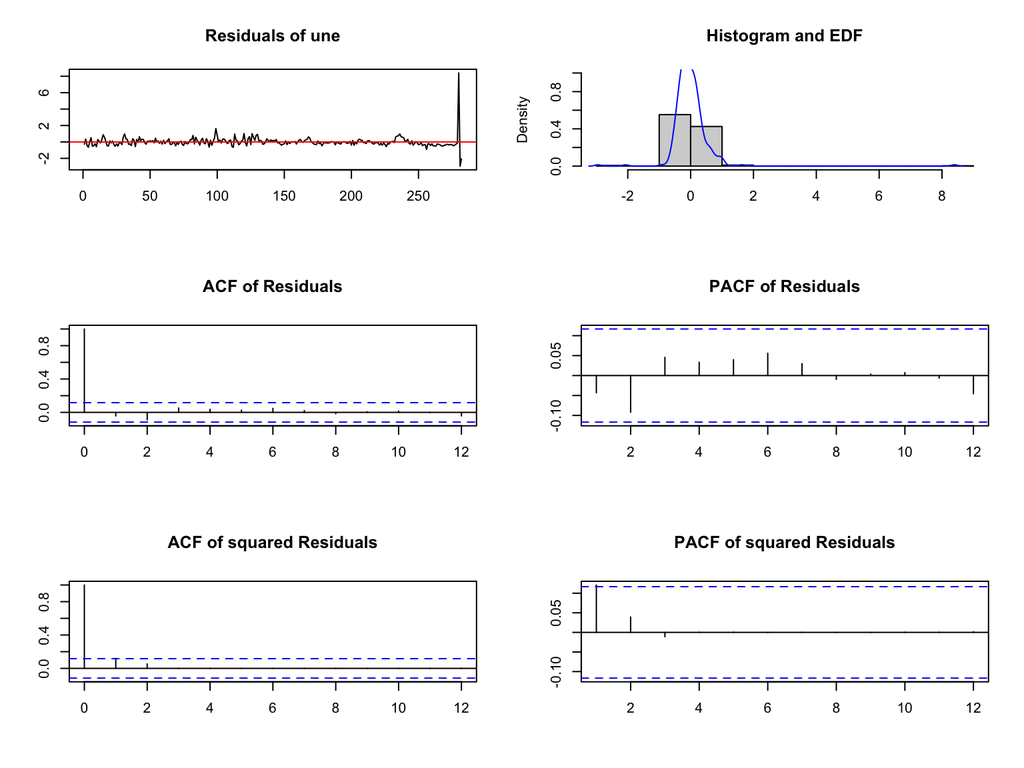

```r
plot(bv.serial, names = "une")
```

```r
# To test for heteroscedasticity in the residuals we can perform a multivariate ARCH Lagrange-Multiplier test.

bv.arch <- arch.test(bv.est, lags.multi = 12, multivariate.only = TRUE)
bv.arch # Once again the p-value that is greater than 5% would indicate the absence of heteroscedasticity. Thus, here we obviously fall this test as 2021 covid 19 shocks.
```

```
##
##  ARCH (multivariate)
##
## data:  Residuals of VAR object bv.est
## Chi-squared = 154.82, df = 108, p-value = 0.002124
```

```r
#  To consider the distribution of the residuals, we could apply a normality test.
bv.norm <- normality.test(bv.est, multivariate.only = TRUE)
bv.norm # where the resulting p-value indicates that the residuals are **not** normally distributed
```

```
## $JB
##
##  JB-Test (multivariate)
##
## data:  Residuals of VAR object bv.est
## Chi-squared = 20296, df = 4, p-value < 2.2e-16
##
##
## $Skewness
##
##  Skewness only (multivariate)
##
## data:  Residuals of VAR object bv.est
## Chi-squared = 814.72, df = 2, p-value < 2.2e-16
##
##
## $Kurtosis
##
##  Kurtosis only (multivariate)
##
## data:  Residuals of VAR object bv.est
## Chi-squared = 19481, df = 2, p-value < 2.2e-16
```

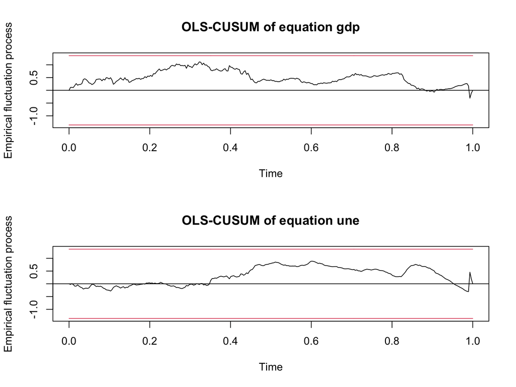

```r
# to test for the structural break in the residuals we can apply a CUSUM test.
bv.cusum <- stability(bv.est, type = "OLS-CUSUM")
plot(bv.cusum) # where there does not appear to be a break in the respective confidence intervals.
```

#### 1.2.4.4 Granger causality, IRFs and variance decompositions

The test for Granger causality is formally implemented by means of a joint hypothesis test. Considers whether all the lags of the k’th variable in the system are jointly significantly different from zero

the null hypothesis is no Granger causality.

We are then able to test for Granger causality, where we note that the null hypothesis of no Granger causality is dismissed in both directions.

```r
bv.cause.gdp <- causality(bv.est, cause = "gdp")
bv.cause.gdp # there is relationship
```

```
## $Granger
##
##  Granger causality H0: gdp do not Granger-cause une
##
## data:  VAR object bv.est
## F-Test = 23.419, df1 = 2, df2 = 554, p-value = 1.724e-10
##
##
## $Instant
##
##  H0: No instantaneous causality between: gdp and une
##
## data:  VAR object bv.est
## Chi-squared = 100.49, df = 1, p-value < 2.2e-16
```

```r
# we can also test it by bootstrap
bv.cause.gdp2 <- causality(bv.est, cause = "gdp", boot = T, boot.runs = 10000)
bv.cause.gdp2
```

```
## $Granger
##
##  Granger causality H0: gdp do not Granger-cause une
##
## data:  VAR object bv.est
## F-Test = 23.419, boot.runs = 10000, p-value = 0.0074
##
##
## $Instant
##
##  H0: No instantaneous causality between: gdp and une
##
## data:  VAR object bv.est
## Chi-squared = 100.49, df = 1, p-value < 2.2e-16
```

```r
bv.cause.une <- causality(bv.est, cause = "une")
bv.cause.une
```

```
## $Granger
##
##  Granger causality H0: une do not Granger-cause gdp
##
## data:  VAR object bv.est
## F-Test = 26.847, df1 = 2, df2 = 554, p-value = 7.437e-12
##
##
## $Instant
##
##  H0: No instantaneous causality between: une and gdp
##
## data:  VAR object bv.est
## Chi-squared = 100.49, df = 1, p-value < 2.2e-16
```

To generate impulse response functions to describe the reponse of output to an unemployment shock, we proceed as follows:

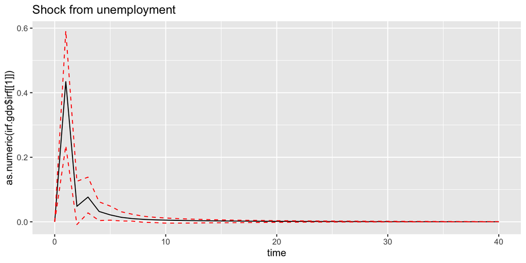

```r
irf.gdp <- irf(bv.est, impulse = "une", response = "gdp",
    n.ahead = 40)
ggplot() +
  geom_line(aes(x = 0:40, y = as.numeric(irf.gdp$irf[[1]]))) +
  geom_line(aes(x = 0:40, y = as.numeric(irf.gdp$Lower[[1]])), linetype = "dashed", color = "red") +
  geom_line(aes(x = 0:40, y = as.numeric(irf.gdp$Upper[[1]])), linetype = "dashed", color = "red") +
  xlab("time") +
  ggtitle("Shock from unemployment")
```

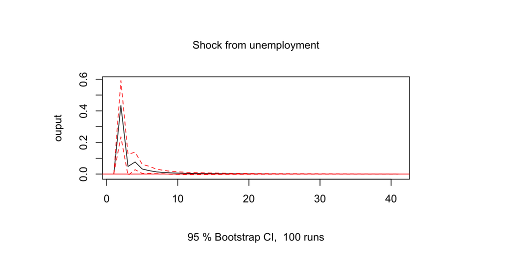

```r
plot(irf.gdp, ylab = "ouput", main = "Shock from unemployment")
```

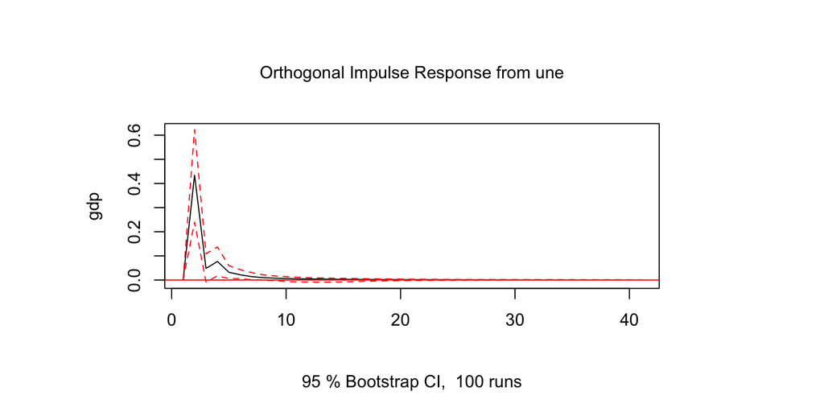

```r
# I do not know how to explain this positive relationship

# then we can also plot this by bootstrap method:
irf.gdp2 <- irf(bv.est, impulse = "une", response = "gdp",
    n.ahead = 40, boot = T)
plot(irf.gdp2)
```

To generate the forecast error variance decompositions we make use of the `fevd` command, where we set the number of steps ahead to ten.

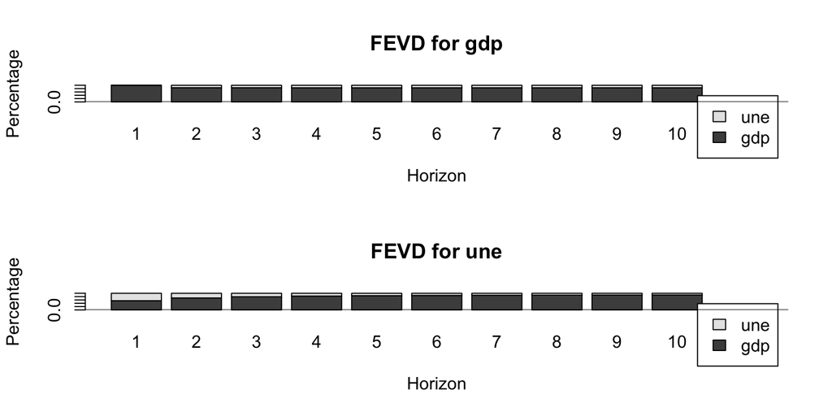

```r
bv.vardec <- fevd(bv.est, n.ahead = 10) # Forecast Error Variance Decomposition
# Computes the forecast error variance decomposition of a VAR(p) for n.ahead steps.
plot(bv.vardec)
```

#### 1.2.4.5 Forecasting

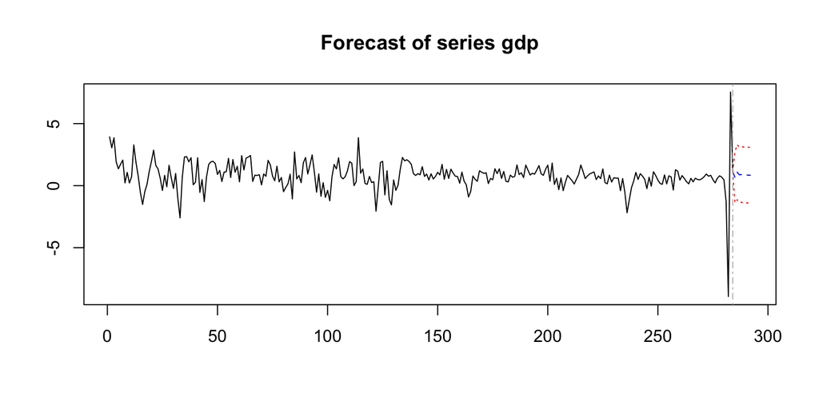

```r
predictions <- predict(bv.est, n.ahead = 8, ci = 0.95)
plot(predictions, names = "gdp")
```

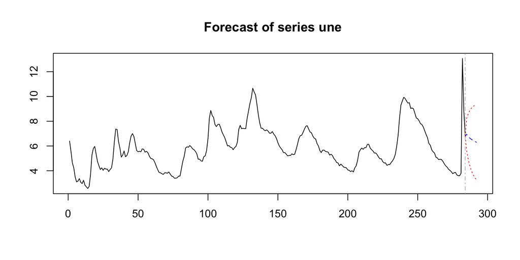

```r
plot(predictions, names = "une")
```

These could also be displayed with the aid of fancharts for the forecasts.

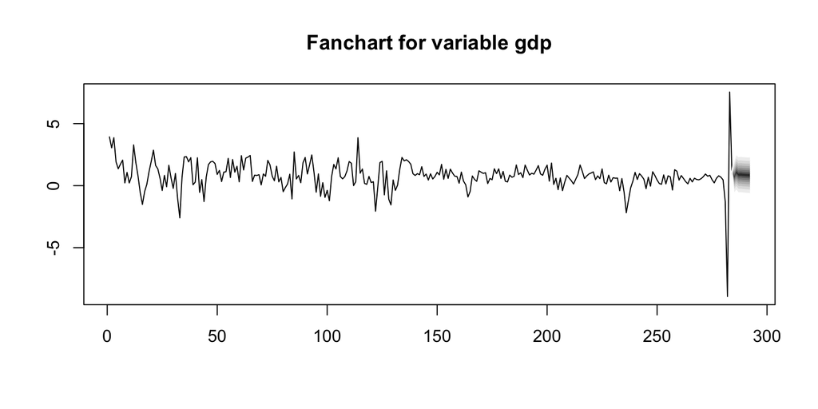

```r
fanchart(predictions, names = "gdp")
```